# Workshop acute exposures: Time-stratified case crossover

21 October, 2022

# Example Case-Crossover Study: Air pollution and wildfire smoke on ED visits

This example studies the impact of air pollution and wildfire smoke on emergency department visits of people experiencing homelessness in San Diego County from 2013-2020. It will go through examples of datasets in two different structures:

1. Individual data: Each row represents one patient (SD_ED_visits_homeless.csv)
2. Time series data: Each row represents one region-date combination with a variable for the number of cases or patients on a given day (SD_ED_visits_homeless_daily_counts.csv)

This data is based on a real study but the health data was modified to protect privacy.

## Loading packages

First, let’s load the packages we will need for this.

```r
library(dplyr)
library(lubridate)
library(survival)
library(ggplot2)
```

## Set working directory and uploading data

We can then upload the exposure and outcome datasets. SD_ED_visits_homeless is a dataset of ED visits in San Diego County of people experiencing homelessness. Each line represents a visit to the ED department. All ED visits in this dataset are from people experiencing homelessness admitted to ED departments in San Diego County.

AP_wildfire_smoke.csv is a dataset of weighted exposure measure based on Point-in-Time (PIT) counts of people experiencing homelessness in San Diego County. All patients in this study will have the same exposure. Exposure variables in this dataset include:

pm25_w: Weighted measure of PM2.5 in micrograms/m^3 based on PIT counts smoke_w: weighted measure of PM2.5 coming from smoke vs_w: weighted measure wind speed sph_w: weighted measure of humidity tmmx_w: weighted measure of maximum temperature

```r
setwd("D:/Lara/workshops_materials/TS_CC_prep/Example_CC/")
SD_ED <- read.csv("SD_ED_visits_homeless.csv")
SD_ED_counts <- read.csv("SD_ED_visits_homeless_daily_counts.csv")
SD_smoke <- read.csv("AP_wildfire_smoke.csv")
head(SD_smoke)
```

```
##        date    pm25_w     vs_w       sph_w   tmmx_w smoke_w
## 1 01jan2013 14.204548 1.811767 0.004566103 289.4216       0
## 2 02jan2013  9.053267 3.517703 0.003403640 291.4380       0
## 3 03jan2013  8.983788 3.429355 0.003307569 292.9615       0
## 4 04jan2013 10.400838 2.630042 0.003184755 292.4000       0
## 5 05jan2013 14.993774 1.127293 0.004094986 291.2538       0
## 6 06jan2013 11.975579 2.867154 0.005521366 288.3422       0
```

# Converting units and taking a look at exposure data

We can change the units to consider every 10 micrograms/m^3 of wildfire smoke and pm2.5. This may be a better unit to use than every 1 unit change as a incremental change of 1 microgram/m^3 may be very small to detect an effect.

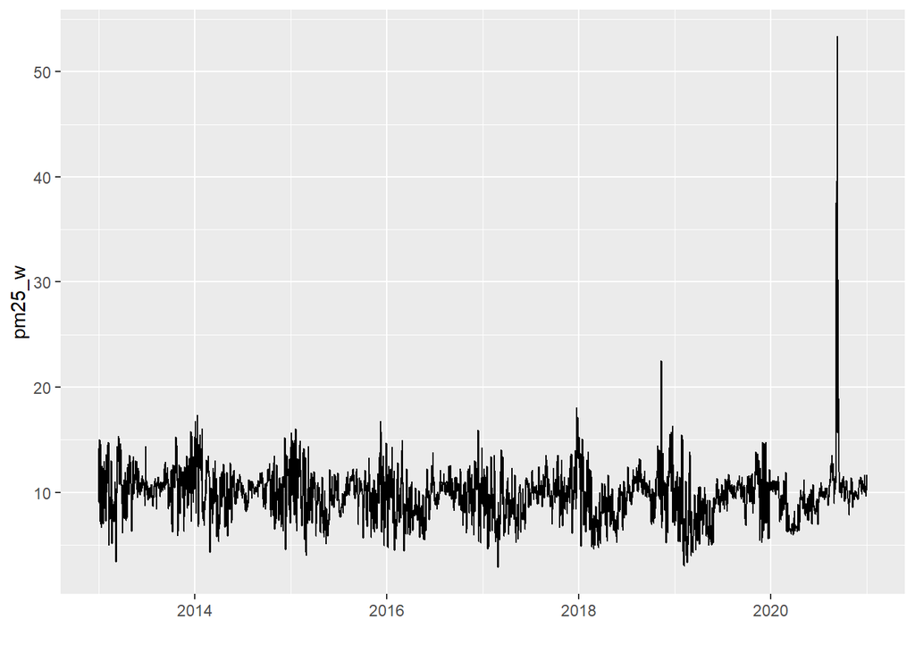

```r
SD_smoke$date<-as.Date(SD_smoke$date, "%d%b%Y")

AP <- ggplot(SD_smoke, aes(x=date, y=pm25_w)) +
  geom_line() +
  xlab("")
AP
```

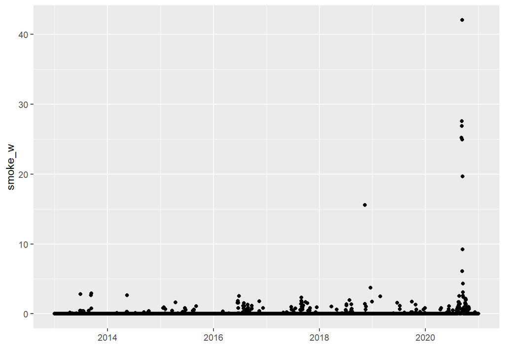

```r
smoke <- ggplot(SD_smoke, aes(x=date, y=smoke_w)) +
  geom_point() +
  xlab("")
smoke
```

```r
SD_smoke$pm25_w_per10<-SD_smoke$pm25_w/10
SD_smoke$smoke_w_per10<-SD_smoke$smoke_w/10
```

## Taking a look at our ED visits Outcome datasets

Take note of the difference in the format between both datasets.

```r
head(SD_ED)
```

```
##   ED_ARRIVAL_DATE HOMELESS
## 1      2013-07-01      Yes
## 2      2013-07-01      Yes
## 3      2013-07-01      Yes
## 4      2013-07-01      Yes
## 5      2013-07-01      Yes
## 6      2013-07-02      Yes
```

```r
head(SD_ED_counts)
```

```
##   ED_ARRIVAL_DATE ED_count
## 1        7/1/2013        5
## 2        7/2/2013       17
## 3        7/3/2013       16
## 4        7/4/2013       10
## 5        7/5/2013       17
## 6        7/6/2013       20
```

```r
summary(SD_ED)
```

```
##  ED_ARRIVAL_DATE      HOMELESS
##  Length:63260       Length:63260
##  Class :character   Class :character
##  Mode  :character   Mode  :character
```

```r
summary(SD_ED_counts)
```

```
##  ED_ARRIVAL_DATE       ED_count
##  Length:2739        Min.   : 4.0
##  Class :character   1st Qu.:18.0
##  Mode  :character   Median :22.0
##                     Mean   :23.1
##                     3rd Qu.:27.0
##                     Max.   :62.0
```

## Getting date, week, weekday and day variables-preparing exposure dataset

We will need the same variables (year, month, weekday) in the exposure dataset for merging.

```r
SD_smoke$wday<-wday(SD_smoke$date)
SD_smoke$week<-week(SD_smoke$date)
SD_smoke$month<-month(SD_smoke$date)
SD_smoke$year<-year(SD_smoke$date)
SD_smoke$day<-format(as.Date(SD_smoke$date,format="%Y-%m-%d"), "%d")

SD_smoke$date<- as.numeric(as.character(as.Date(SD_smoke$date, format = "%d%m%Y"), format="%Y%m%d"))
```

```r
SD_smoke <-SD_smoke %>%
  mutate(SD_smoke, smoke_lag1=lag(smoke_w_per10, order_by=date))
```

# Dataset prep and analysis for individual level data

## Getting date, week, weekday and day variables- preparing ED visits dataset

To format the datasets in case crossover format, we need each case to be matched with 4-5 exposure lines for the same day of the week within the same month that the case occurred. In order to do this, we will need a variable for the week, weekday and day in both exposure and health datasets. Case day is the date for which the patient visited the ED which will be used for exposure. We also create a unique identifier for each row (or patient) in our ED visits dataset. The last line is to get the date in numeric format which will make it easier for the merging later.

```r
SD_ED$case_date<-SD_ED$ED_ARRIVAL_DATE
SD_ED$year<-year(SD_ED$ED_ARRIVAL_DATE)
SD_ED$month<-month(SD_ED$ED_ARRIVAL_DATE)
SD_ED$wday<-wday(SD_ED$case_date)
SD_ED$ID_grp<-seq.int(nrow(SD_ED))

SD_ED$case_date<- as.numeric(as.character(as.Date(SD_ED$case_date, format = "%Y-%m-%d"), format="%Y%m%d"))
```

## Converting to case-crossover format

We want a dataset where each case (in this original datset, represented by each row) has it’s own controls. To do this, we merge the ED visits dataset with the exposure dataset, matching by weekday, year and month. As all patients in this study are considered to have the same exposure, we don’t need to include geographic unit, but if there was differential exposure we would want to match by zip code/county or the geographic unit we have the exposure estimated.

```r
SD_ED_cc <- SD_ED %>%
  left_join(SD_smoke, by = c("year", "month", "wday")) %>%  #merge the exposure data
  mutate(case = if_else(case_date==date, 1, 0))            #generate case and control observations


head(SD_ED_cc, n=10)
```

```
##    ED_ARRIVAL_DATE HOMELESS case_date year month wday ID_grp     date    pm25_w
## 1       2013-07-01      Yes  20130701 2013     7    2      1 20130701 10.215781
## 2       2013-07-01      Yes  20130701 2013     7    2      1 20130708  9.924143
## 3       2013-07-01      Yes  20130701 2013     7    2      1 20130715  9.704300
## 4       2013-07-01      Yes  20130701 2013     7    2      1 20130722 10.751298
## 5       2013-07-01      Yes  20130701 2013     7    2      1 20130729 10.499799
## 6       2013-07-01      Yes  20130701 2013     7    2      2 20130701 10.215781
## 7       2013-07-01      Yes  20130701 2013     7    2      2 20130708  9.924143
## 8       2013-07-01      Yes  20130701 2013     7    2      2 20130715  9.704300
## 9       2013-07-01      Yes  20130701 2013     7    2      2 20130722 10.751298
## 10      2013-07-01      Yes  20130701 2013     7    2      2 20130729 10.499799
##        vs_w      sph_w   tmmx_w    smoke_w pm25_w_per10 smoke_w_per10 week day
## 1  2.824555 0.01205851 298.1814 0.29208779    1.0215781   0.029208779   26  01
## 2  2.779113 0.01117512 301.5527 0.00000000    0.9924143   0.000000000   27  08
## 3  2.579449 0.01166844 300.5326 0.00000000    0.9704300   0.000000000   28  15
```

[output cut: 18 more lines]

## Descriptive comparison

We can start by comparing our exposure in the cases and controls.

```r
SD_ED_cc %>%
  group_by(case) %>%
  summarize(mean=mean(smoke_w_per10))
```

```
## # A tibble: 2 x 2
##    case   mean
##   <dbl>  <dbl>
## 1     0 0.0172
## 2     1 0.0176
```

```r
SD_ED_cc %>%
  group_by(case) %>%
  summarize(mean=mean(smoke_w_per10))
```

```
## # A tibble: 2 x 2
##    case   mean
##   <dbl>  <dbl>
## 1     0 0.0172
## 2     1 0.0176
```

## Analysis

Now that we have the dataset in the right format, we can run a conditional logistic regression to study the effect of wildfire smoke and ambient PM2.5 on ED visits of people experiencing homelessness in San Diego County.

```r
model_smoke<-clogit(case~ smoke_w_per10 + vs_w +sph_w+ tmmx_w+ strata(ID_grp), data=SD_ED_cc)
summary(model_smoke)
```

```
## Call:
## coxph(formula = Surv(rep(1, 277241L), case) ~ smoke_w_per10 +
##     vs_w + sph_w + tmmx_w + strata(ID_grp), data = SD_ED_cc,
##     method = "exact")
##
##   n= 277241, number of events= 63044
##
##                    coef exp(coef)  se(coef)      z Pr(>|z|)
## smoke_w_per10  0.001062  1.001062  0.027790  0.038   0.9695
## vs_w           0.001478  1.001479  0.004711  0.314   0.7538
## sph_w         -6.144001  0.002146  3.639494 -1.688   0.0914 .
## tmmx_w        -0.002085  0.997917  0.001312 -1.589   0.1120
## ---
## Signif. codes:  0 '***' 0.001 '**' 0.01 '*' 0.05 '.' 0.1 ' ' 1
##
##               exp(coef) exp(-coef) lower .95 upper .95
## smoke_w_per10  1.001062     0.9989 9.480e-01     1.057
## vs_w           1.001479     0.9985 9.923e-01     1.011
## sph_w          0.002146   465.9141 1.713e-06     2.689
## tmmx_w         0.997917     1.0021 9.954e-01     1.000
##
## Concordance= 0.504  (se = 0.002 )
## Likelihood ratio test= 5.42  on 4 df,   p=0.2
## Wald test            = 5.42  on 4 df,   p=0.2
## Score (logrank) test = 5.42  on 4 df,   p=0.2
```

```r
model_ap<-clogit(case~ pm25_w_per10 + vs_w +sph_w+ tmmx_w+ strata(ID_grp), data=SD_ED_cc)
summary(model_ap)
```

```
## Call:
## coxph(formula = Surv(rep(1, 277241L), case) ~ pm25_w_per10 +
##     vs_w + sph_w + tmmx_w + strata(ID_grp), data = SD_ED_cc,
##     method = "exact")
##
##   n= 277241, number of events= 63044
##
##                   coef exp(coef)  se(coef)      z Pr(>|z|)
## pm25_w_per10  0.005429  1.005444  0.022130  0.245   0.8062
## vs_w          0.002031  1.002033  0.005220  0.389   0.6972
## sph_w        -6.273627  0.001885  3.678655 -1.705   0.0881 .
## tmmx_w       -0.002157  0.997845  0.001344 -1.605   0.1085
## ---
## Signif. codes:  0 '***' 0.001 '**' 0.01 '*' 0.05 '.' 0.1 ' ' 1
##
##              exp(coef) exp(-coef) lower .95 upper .95
## pm25_w_per10  1.005444     0.9946 9.628e-01     1.050
## vs_w          1.002033     0.9980 9.918e-01     1.012
## sph_w         0.001885   530.3978 1.394e-06     2.551
## tmmx_w        0.997845     1.0022 9.952e-01     1.000
##
## Concordance= 0.503  (se = 0.002 )
## Likelihood ratio test= 5.48  on 4 df,   p=0.2
## Wald test            = 5.48  on 4 df,   p=0.2
## Score (logrank) test = 5.48  on 4 df,   p=0.2
```

# Dataset prep and analysis for time series data

This step will be the same as above. We still need variables for weekday, week, month and year. For this dataset, the group identifier will instead represent a day in which there were ED visits.

```r
SD_ED_counts$case_date<- as.Date(SD_ED_counts$ED_ARRIVAL_DATE, format = "%m/%d/%Y")

SD_ED_counts$year<-year(SD_ED_counts$case_date)
SD_ED_counts$month<-month(SD_ED_counts$case_date)
SD_ED_counts$wday<-wday(SD_ED_counts$case_date)
SD_ED_counts$ID_grp<-seq.int(nrow(SD_ED_counts))

SD_ED_counts$case_date<- as.numeric(as.character(as.Date(SD_ED_counts$case_date, format = "%Y-%m-%d"), format="%Y%m%d"))
```

## Converting to case-crossover format

This step will again be the same but we are merging exposure data based on days in our outcome time series dataset. Let’s see what the dataset look like now.

```r
SD_ED_count_cc <- SD_ED_counts %>%
  left_join(SD_smoke, by = c("year", "month", "wday")) %>%  #merge the exposure data
  mutate(case = if_else(case_date==date, 1, 0))            #generate case and control observations

head(SD_ED_count_cc)
```

```
##   ED_ARRIVAL_DATE ED_count case_date year month wday ID_grp     date    pm25_w
## 1        7/1/2013        5  20130701 2013     7    2      1 20130701 10.215781
## 2        7/1/2013        5  20130701 2013     7    2      1 20130708  9.924143
## 3        7/1/2013        5  20130701 2013     7    2      1 20130715  9.704300
## 4        7/1/2013        5  20130701 2013     7    2      1 20130722 10.751298
## 5        7/1/2013        5  20130701 2013     7    2      1 20130729 10.499799
## 6        7/2/2013       17  20130702 2013     7    3      2 20130702 11.046881
##       vs_w      sph_w   tmmx_w    smoke_w pm25_w_per10 smoke_w_per10 week day
## 1 2.824555 0.01205851 298.1814 0.29208779    1.0215781   0.029208779   26  01
## 2 2.779113 0.01117512 301.5527 0.00000000    0.9924143   0.000000000   27  08
## 3 2.579449 0.01166844 300.5326 0.00000000    0.9704300   0.000000000   28  15
## 4 1.570662 0.01295529 299.3706 0.00000000    1.0751298   0.000000000   29  22
## 5 1.823663 0.01122074 299.8459 0.09035381    1.0499799   0.009035381   30  29
## 6 1.829483 0.01206628 303.0844 0.31788734    1.1046881   0.031788734   27  02
##   smoke_lag1 case
## 1 0.04710483    1
## 2 0.00000000    0
## 3 0.00000000    0
## 4 0.00000000    0
## 5 0.00000000    0
## 6 0.02920878    1
```

## Analysis

Because this original dataset came in a time series format, we will add a weight command to account for differences in the number of cases each day. If you are interested in looking at different diagnoses or outcomes, this is an easier way to have the dataset formatted for this. You can use the weight command to specify the outcome of interest for the final model.

```r
model_tcount_smoke<-clogit(case~ smoke_w_per10 + vs_w +sph_w+ tmmx_w+ strata(ID_grp), weights=ED_count, method="approximate" , data=SD_ED_count_cc)
summary(model_tcount_smoke)
```

```
## Call:
## coxph(formula = Surv(rep(1, 12014L), case) ~ smoke_w_per10 +
##     vs_w + sph_w + tmmx_w + strata(ID_grp), data = SD_ED_count_cc,
##     weights = ED_count, method = "breslow")
##
##   n= 12014, number of events= 2730
##
##                    coef exp(coef)  se(coef)      z Pr(>|z|)
## smoke_w_per10  0.001062  1.001062  0.027790  0.038   0.9695
## vs_w           0.001478  1.001479  0.004711  0.314   0.7538
## sph_w         -6.144001  0.002146  3.639494 -1.688   0.0914 .
## tmmx_w        -0.002085  0.997917  0.001312 -1.589   0.1120
## ---
## Signif. codes:  0 '***' 0.001 '**' 0.01 '*' 0.05 '.' 0.1 ' ' 1
##
##               exp(coef) exp(-coef) lower .95 upper .95
## smoke_w_per10  1.001062     0.9989 9.480e-01     1.057
## vs_w           1.001479     0.9985 9.923e-01     1.011
## sph_w          0.002146   465.9141 1.713e-06     2.689
## tmmx_w         0.997917     1.0021 9.954e-01     1.000
##
## Concordance= 0.507  (se = 0.011 )
## Likelihood ratio test= 5.42  on 4 df,   p=0.2
## Wald test            = 5.42  on 4 df,   p=0.2
## Score (logrank) test = 5.42  on 4 df,   p=0.2
```

```r
model_tcount_ap<-clogit(case~ pm25_w_per10 + vs_w +sph_w+ tmmx_w+ strata(ID_grp),  weights=ED_count, method="approximate" , data=SD_ED_count_cc)
summary(model_tcount_ap)
```

```
## Call:
## coxph(formula = Surv(rep(1, 12014L), case) ~ pm25_w_per10 + vs_w +
##     sph_w + tmmx_w + strata(ID_grp), data = SD_ED_count_cc, weights = ED_count,
##     method = "breslow")
##
##   n= 12014, number of events= 2730
##
##                   coef exp(coef)  se(coef)      z Pr(>|z|)
## pm25_w_per10  0.005429  1.005444  0.022130  0.245   0.8062
## vs_w          0.002031  1.002033  0.005220  0.389   0.6972
## sph_w        -6.273627  0.001885  3.678655 -1.705   0.0881 .
## tmmx_w       -0.002157  0.997845  0.001344 -1.605   0.1085
## ---
## Signif. codes:  0 '***' 0.001 '**' 0.01 '*' 0.05 '.' 0.1 ' ' 1
##
##              exp(coef) exp(-coef) lower .95 upper .95
## pm25_w_per10  1.005444     0.9946 9.628e-01     1.050
## vs_w          1.002033     0.9980 9.918e-01     1.012
## sph_w         0.001885   530.3978 1.394e-06     2.551
## tmmx_w        0.997845     1.0022 9.952e-01     1.000
##
## Concordance= 0.507  (se = 0.011 )
## Likelihood ratio test= 5.48  on 4 df,   p=0.2
## Wald test            = 5.48  on 4 df,   p=0.2
## Score (logrank) test = 5.48  on 4 df,   p=0.2
```

## Comparing results

Because we started with different formats of the same dataset, results should be equivalent. We can compare them here.

```r
summary(model_smoke)
```

```
## Call:
## coxph(formula = Surv(rep(1, 277241L), case) ~ smoke_w_per10 +
##     vs_w + sph_w + tmmx_w + strata(ID_grp), data = SD_ED_cc,
##     method = "exact")
##
##   n= 277241, number of events= 63044
##
##                    coef exp(coef)  se(coef)      z Pr(>|z|)
## smoke_w_per10  0.001062  1.001062  0.027790  0.038   0.9695
## vs_w           0.001478  1.001479  0.004711  0.314   0.7538
## sph_w         -6.144001  0.002146  3.639494 -1.688   0.0914 .
## tmmx_w        -0.002085  0.997917  0.001312 -1.589   0.1120
## ---
## Signif. codes:  0 '***' 0.001 '**' 0.01 '*' 0.05 '.' 0.1 ' ' 1
##
##               exp(coef) exp(-coef) lower .95 upper .95
## smoke_w_per10  1.001062     0.9989 9.480e-01     1.057
## vs_w           1.001479     0.9985 9.923e-01     1.011
## sph_w          0.002146   465.9141 1.713e-06     2.689
## tmmx_w         0.997917     1.0021 9.954e-01     1.000
##
## Concordance= 0.504  (se = 0.002 )
## Likelihood ratio test= 5.42  on 4 df,   p=0.2
## Wald test            = 5.42  on 4 df,   p=0.2
## Score (logrank) test = 5.42  on 4 df,   p=0.2
```

```r
summary(model_tcount_smoke)
```

```
## Call:
## coxph(formula = Surv(rep(1, 12014L), case) ~ smoke_w_per10 +
##     vs_w + sph_w + tmmx_w + strata(ID_grp), data = SD_ED_count_cc,
##     weights = ED_count, method = "breslow")
##
##   n= 12014, number of events= 2730
##
##                    coef exp(coef)  se(coef)      z Pr(>|z|)
## smoke_w_per10  0.001062  1.001062  0.027790  0.038   0.9695
## vs_w           0.001478  1.001479  0.004711  0.314   0.7538
## sph_w         -6.144001  0.002146  3.639494 -1.688   0.0914 .
## tmmx_w        -0.002085  0.997917  0.001312 -1.589   0.1120
## ---
## Signif. codes:  0 '***' 0.001 '**' 0.01 '*' 0.05 '.' 0.1 ' ' 1
##
##               exp(coef) exp(-coef) lower .95 upper .95
## smoke_w_per10  1.001062     0.9989 9.480e-01     1.057
## vs_w           1.001479     0.9985 9.923e-01     1.011
## sph_w          0.002146   465.9141 1.713e-06     2.689
## tmmx_w         0.997917     1.0021 9.954e-01     1.000
##
## Concordance= 0.507  (se = 0.011 )
## Likelihood ratio test= 5.42  on 4 df,   p=0.2
## Wald test            = 5.42  on 4 df,   p=0.2
## Score (logrank) test = 5.42  on 4 df,   p=0.2
```

```r
summary(model_ap)
```

```
## Call:
## coxph(formula = Surv(rep(1, 277241L), case) ~ pm25_w_per10 +
##     vs_w + sph_w + tmmx_w + strata(ID_grp), data = SD_ED_cc,
##     method = "exact")
##
##   n= 277241, number of events= 63044
##
##                   coef exp(coef)  se(coef)      z Pr(>|z|)
## pm25_w_per10  0.005429  1.005444  0.022130  0.245   0.8062
## vs_w          0.002031  1.002033  0.005220  0.389   0.6972
## sph_w        -6.273627  0.001885  3.678655 -1.705   0.0881 .
## tmmx_w       -0.002157  0.997845  0.001344 -1.605   0.1085
## ---
## Signif. codes:  0 '***' 0.001 '**' 0.01 '*' 0.05 '.' 0.1 ' ' 1
##
##              exp(coef) exp(-coef) lower .95 upper .95
## pm25_w_per10  1.005444     0.9946 9.628e-01     1.050
## vs_w          1.002033     0.9980 9.918e-01     1.012
## sph_w         0.001885   530.3978 1.394e-06     2.551
## tmmx_w        0.997845     1.0022 9.952e-01     1.000
##
## Concordance= 0.503  (se = 0.002 )
## Likelihood ratio test= 5.48  on 4 df,   p=0.2
## Wald test            = 5.48  on 4 df,   p=0.2
## Score (logrank) test = 5.48  on 4 df,   p=0.2
```

```r
summary(model_tcount_ap)
```

```
## Call:
## coxph(formula = Surv(rep(1, 12014L), case) ~ pm25_w_per10 + vs_w +
##     sph_w + tmmx_w + strata(ID_grp), data = SD_ED_count_cc, weights = ED_count,
##     method = "breslow")
##
##   n= 12014, number of events= 2730
##
##                   coef exp(coef)  se(coef)      z Pr(>|z|)
## pm25_w_per10  0.005429  1.005444  0.022130  0.245   0.8062
## vs_w          0.002031  1.002033  0.005220  0.389   0.6972
## sph_w        -6.273627  0.001885  3.678655 -1.705   0.0881 .
## tmmx_w       -0.002157  0.997845  0.001344 -1.605   0.1085
## ---
## Signif. codes:  0 '***' 0.001 '**' 0.01 '*' 0.05 '.' 0.1 ' ' 1
##
##              exp(coef) exp(-coef) lower .95 upper .95
## pm25_w_per10  1.005444     0.9946 9.628e-01     1.050
## vs_w          1.002033     0.9980 9.918e-01     1.012
## sph_w         0.001885   530.3978 1.394e-06     2.551
## tmmx_w        0.997845     1.0022 9.952e-01     1.000
##
## Concordance= 0.507  (se = 0.011 )
## Likelihood ratio test= 5.48  on 4 df,   p=0.2
## Wald test            = 5.48  on 4 df,   p=0.2
## Score (logrank) test = 5.48  on 4 df,   p=0.2
```